# Introduction

### Exercises

- Use `vapply()` to:
  - Compute the standard deviation of every column in a numeric data frame.
  - Compute the standard deviation of of every numeric column in a mixed data frame (Hint: you'll need to use `vapply()` twice)
- Recall: why is using `sapply()` to get the `class()` of each element in a data frame dangerous?
- The following code simulates the performance of a t-test for non-normal data. Use `sapply()` and an anonymous function to extract the p value from every trial. Extra challenge: get rid of the anonymous function and use the `'[[` function.

```r
trials <- replicate(100, t.test(rpois(10, 10), rpois(7, 10)),
  simplify = FALSE)
```

- Implement a combination of `Map()` and `vapply()` to create an `lapply()` variant that iterates in parallel over all of its inputs and stores its outputs in a vector (or a matrix). What arguments should the function take?
- What does `replicate()` do? What sort of for loop does it eliminate? Why do its arguments differ from `lapply()` and friends?
- Implement `mcsapply()`, a multicore version of `sapply()`. Can you implement `mcvapply()` a parallel version of `vapply()`? Why/why not?
- Implement a version of `lapply()` that supplies `f()` with both the name and the value of each component.

## Data structure functionals

As well as functionals that exist to eliminate common looping constructs, another family of functionals works to eliminate loops for common data manipulation tasks. In this section, we'll give a brief overview of the available options. We'll show you some of the available options, hint at how they can help you, and point you in the right direction to learn more. We'll cover three categories of data structure functionals:

- base functions for working with matrices: `apply()`, `sweep()` and `outer()`
- `tapply()`, which summarises a vector divided into groups by the values of another vector
- the `plyr` package, which generalises the ideas of `tapply()` to work with inputs of data frames, lists and arrays, and outputs of data frames, lists, arrays and nothing

### Matrix and array operations

So far, all the functionals we've seen work with 1d input structures. The three functionals in this section provide useful tools for working with high-dimensional data structures. `apply()` is a variant of `sapply()` that works with matrices and arrays. You can think of it as an operation that summarises a matrix or array, collapsing each row or column to a single number. It has four arguments:

- `X`, the matrix or array to summarise
- `MARGIN`, an integer vector giving the dimensions to summarise over, 1 = rows, 2 = columns, etc
- `FUN`, a summary function
- `...` other arguments passed on to `FUN`

A typical example of `apply()` looks like this

```r
a <- matrix(1:20, nrow = 5)
apply(a, 1, mean)
```

```
## [1]  8.5  9.5 10.5 11.5 12.5
```

```r
apply(a, 2, mean)
```

```
## [1]  3  8 13 18
```

There are a few caveats to using `apply()`: it does not have a simplify argument, so you can never be completely sure what type of output you will get. This generally means that `apply()` is not safe to use inside a function, unless you carefully check the inputs. `apply()` is also not idempotent in the sense that if the summary function is the identity operator, the output is not always the same as the input:

```r
a1 <- apply(a, 1, identity)
identical(a, a1)
```

```
## [1] FALSE
```

```r
identical(a, t(a1))
```

```
## [1] TRUE
```

```r
a2 <- apply(a, 2, identity)
identical(a, a2)
```

```
## [1] TRUE
```

(You can put high-dimensional arrays back in the right order using `aperm()`, or use `plyr::aaply()`, which is idempotent.)

`sweep()` is a function that allows you to "sweep" out the values of a summary statistic. It is most often useful in conjunction with `apply()` and it often used to standardise arrays in some way. The following example scales a matrix so that all values lie between 0 and 1.

```r
x <- matrix(runif(20), nrow = 4)
x1 <- sweep(x, 1, apply(x, 1, min))
```

[output not shown]

```r
x2 <- sweep(x1, 1, apply(x1, 1, max), "/")
```

[output not shown]

The final matrix functional is `outer()`. It's a little different in that it takes multiple vector inputs and creates a matrix or array output where the input function is run over every combination of the inputs:

```r
# Create a times table
outer(1:9, 1:9, "*")
```

```
##       [,1] [,2] [,3] [,4] [,5] [,6] [,7] [,8] [,9]
##  [1,]    1    2    3    4    5    6    7    8    9
##  [2,]    2    4    6    8   10   12   14   16   18
##  [3,]    3    6    9   12   15   18   21   24   27
##  [4,]    4    8   12   16   20   24   28   32   36
##  [5,]    5   10   15   20   25   30   35   40   45
##  [6,]    6   12   18   24   30   36   42   48   54
##  [7,]    7   14   21   28   35   42   49   56   63
##  [8,]    8   16   24   32   40   48   56   64   72
##  [9,]    9   18   27   36   45   54   63   72   81
```

Good places to learn more about `apply()` and friends are:

- ["Using apply, sapply, lapply in R"](http://petewerner.blogspot.com/2012/12/using-apply-sapply-lapply-in-r.html) by Peter Werner.
- ["The infamous apply function"](http://rforpublichealth.blogspot.no/2012/09/the-infamous-apply-function.html) by Slawa Rokicki.
- ["The R apply function – a tutorial with examples"](http://forgetfulfunctor.blogspot.com/2011/07/r-apply-function-tutorial-with-examples.html) by axiomOfChoice.
- The stack overflow question ["R Grouping functions: sapply vs. lapply vs. apply. vs. tapply vs. by vs. aggregate vs"](http://stackoverflow.com/questions/3505701).

### Group apply

You can think about `tapply()` as a generalisation to `apply()` that allows for "ragged" arrays, where each row can have different numbers of columns. This is often needed when you're trying to summarise a data set. For example, imagine you've collected some pulse rate from a medical trial, and you want to compare the two groups:

```r
pulse <- round(rnorm(22, 70, 10 / 3)) + rep(c(0, 5), c(10, 12))
group <- rep(c("A", "B"), c(10, 12))

tapply(pulse, group, length)
```

```
##  A  B
## 10 12
```

```r
tapply(pulse, group, mean)
```

```
##    A    B
## 69.9 75.5
```

It's easiest to understand how `tapply()` works by first creating a "ragged" data structure from the inputs. This is the job of the `split()` function, which takes two inputs and returns a list, where all the elements in the first vector with equal entries in the second vector get put in the same element of the list:

```r
split(pulse, group)
```

```
## $A
##  [1] 71 69 66 76 68 74 71 67 67 70
##
## $B
##  [1] 78 75 77 74 77 78 75 76 75 72 71 78
```

Then you can see that `tapply()` is just the combination of `split()` and `sapply()`:

```r
tapply2 <- function(x, group, f, ..., simplify = TRUE) {
  pieces <- split(x, group)
  sapply(pieces, f, simplify = simplify)
}
tapply2(pulse, group, length)
```

```
##  A  B
## 10 12
```

```r
tapply2(pulse, group, mean)
```

```
##    A    B
## 69.9 75.5
```

Be able to rewrite our `tapply()` as a combination of `split()` and `sapply()` is a good indication that we've been able to extract independent pieces that we can recombine to solve new problems.

### The plyr package

One challenge with using the base functionals is that they have grown organically over time, and have been written by multiple authors. This means that they are not very consistent. For example,

- The simplify argument is called `simplify` in `tapply()` and `sapply()`, but `SIMPLIFY` for `mapply()`, and `apply()` lacks the argument altogether.
- `vapply()` is a variant of `sapply()` that allows you to describe what the output should be, but there are no corresponding variants of `tapply()`, `apply()`, or `Map()`.
- The first to most functionals is the vector, but the first argument to `Map()` is the function.

This makes learning these operators challenging, as you have to memorise all of the variations. Additionally, if you think about the combination of input and output types, base R only provides a partial set of functions:

|  | list | data frame | array |
| --- | --- | --- | --- |
| list | lapply |  | sapply |
| data frame | by |  |  |
| array |  |  | apply |

This was one of the driving forces behind the creation of the plyr package, which provides consistently named functions with consistently named arguments and implements all combinations of input and output data structures:

|  | list | data frame | array |
| --- | --- | --- | --- |
| list | llply | ldply | laply |
| data frame | dlply | ddply | daply |
| array | alply | adply | aaply |

Each of these functions splits up the input, applies a function to each piece and then joins the results back together. Overall, this process is called "split-apply-combine", and you can read more about it and plyr in [The Split-Apply-Combine Strategy for Data Analysis](http://www.jstatsoft.org/v40/i01/), an open-access article published in the Journal of Statistical Software.

### Exercises

- How does `apply()` arrange the output. Read the documentation and perform some experiments.
- There's no equivalent to `split()` + `vapply()`. Should there be? When would it be useful? Implement it yourself.
- Implement a pure R version of `split()`. (Hint: use unique and subseting)
- What other types of input and output are missing? Brainstorm before you look up some answers in the [plyr paper](http://www.jstatsoft.org/v40/i01/)

## Functional programming

Another way of thinking about functionals is as a set of general tools for altering, subsetting and collapsing lists. Every functional programming has three tools for this: `Map()`, `Reduce()`, and `Filter()`. We've seen `Map()` already, and the following sections described `Reduce()`, a powerful tool for extending two-argument functions, and `Filter()`, a member of an important class of functionals that work with predicates, functions that return a single boolean.

### `Reduce()`

`Reduce()` recursively reduces a vector, `x`, to a single value by recursively calling a function `f` with two arguments at a time. It combines the first two elements with `f`, then combines the result of that call with the third element, and so on. Reduce is also known as fold, because it folds together adjacent elements in the list.

The following two examples show what `Reduce` does with an infix and prefix function:

```r
Reduce(`+`, 1:3)
((1 + 2) + 3)

Reduce(sum, 1:3)
sum(sum(1, 2), 3)
```

As you might have come to expect by now, the essence of `Reduce()` can be described by a simple for loop:

```r
Reduce2 <- function(f, x) {
  out <- x[[1]]
  for(i in seq(2, length(x))) {
    out <- f(out, x[[i]])
  }
  out
}
```

The real `Reduce()` is more complicated because it includes arguments to control whether the values are reduced from the left or from the right (`right`), an optional initial value (`init`), and an option to output every intermediate result (`accumulate`).

Reduce is an elegant way of turning binary functions into functions that can deal with any number of arguments. It's useful for implementing many types of recursive operations, like merges and intersections (We'll see another use in the final case study). For example, imagine you had a list of numeric vectors, and you wanted to find the values that occurred in every element:

```r
l <- replicate(5, sample(1:10, 15, rep = T), simplify = FALSE)
l
```

```
## [[1]]
##  [1] 9 9 4 7 9 6 3 4 6 1 7 2 7 5 4
##
## [[2]]
##  [1]  9  9  5  2  4  3  7  3  3  6  7  5 10  2  6
##
## [[3]]
##  [1]  5  1  3  1  1 10  6  6  5  1  9  2  9  4  3
##
## [[4]]
##  [1] 1 9 7 3 2 5 2 2 1 8 2 6 4 1 8
##
## [[5]]
##  [1]  2  1  4 10  4  1  1  5 10  1  8  6  7  7  4
```

You could do that by intersecting each element in turn:

```r
intersect(intersect(intersect(intersect(l[[1]], l[[2]]),
  l[[3]]), l[[4]]), l[[5]])
```

```
## [1] 4 6 2 5
```

That's hard to read because of the dagwood sandwich problem, and is equivalent to:

```r
Reduce(intersect, l)
```

```
## [1] 4 6 2 5
```

### Predicate functionals

A **predicate** is a function that returns a single `TRUE` or `FALSE`, like `is.character`, `all`, or `is.NULL`. `is.na` isn't a predicate function because it returns a vector of values. Predicate functionals make it easy to apply predicates to lists or data frames. There are a three useful predicate functionals in base R: `Filter()`, `Find()` and `Position()`.

- `Filter`: returns a new vector containing only elements where the predicate is `TRUE`.
- `Find()`: return the first element that matches the predicate (or the last element if `right = TRUE`).
- `Position()`: return the position of the first element that matches the predicate (or the last element if `right = TRUE`).

Another useful functional makes it easy to generate a logical vector from a list (or a data frame) and a predicate:

```r
where <- function(x, f) {
  vapply(x, f, logical(1))
}
```

The following example shows how you might use these functionals with a data frame:

```r
str(Filter(is.character, iris))
```

```
## 'data.frame':   150 obs. of  0 variables
```

```r
where(iris, is.character)
```

```
## Sepal.Length  Sepal.Width Petal.Length  Petal.Width      Species
##        FALSE        FALSE        FALSE        FALSE        FALSE
```

```r
str(Find(is.character, iris))
```

```r
Position(is.character, iris)
```

```
## [1] NA
```

One function I use a lot is `compact()`:

```r
compact <- function(x) Filter(function(y) !is.null(y), x)
```

It removes all null elements from a list - you'll see it again in the [[function operators]] chapter.

### Exercises

- Use `Filter()` and `vapply()` to create a function that applies a summary statistic to every column in a data frame.
- What's the relationship between `which()` and `Position()`?
- Re-write `compact` to eliminate the anonymous function.
- Implement `Any`, a function that takes a list and a predicate function, and returns `TRUE` if the predicate function returns `TRUE` for any of the inputs. Implement the complementary `All` function.
- Implement the `span` function from Haskell, which given a list `x` and a predicate function `f`, returns the longest sequential run of elements where the predicate is true. (Hint: you might find `rle()` helpful. Make sure to read the source and figure out how it works)

## Mathematical functionals

Functionals are very common in mathematics. The limit, the maximum, the roots (the set of points where `f(x) = 0`), and the definite integral are all functionals: given a function, they return a single number (or a vector of numbers). At first glance, these functions don't seem to fit in with the theme of eliminating loops, but if you dig deeper you'll see all of them are implemented using an algorithm that involves iteration.

In this section we'll explore some of R's built-in mathematical functionals. There are three functions that work with functions that return a single numeric value:

- `integrate`: find the area under the curve given by `f`
- `uniroot`: find where `f` hits zero
- `optimise`: find location of lowest (or highest) value of `f`

Let's explore how these are used with a simple function, `sin`:

```r
integrate(sin, 0, pi)
```

```
## 2 with absolute error < 2.2e-14
```

```r
uniroot(sin, pi * c(1 / 2, 3 / 2))
```

```
## $root
## [1] 3.142
##
## $f.root
## [1] 1.225e-16
##
## $iter
## [1] 2
##
## $estim.prec
## [1] 6.104e-05
```

```r
optimise(sin, c(0, 2 * pi))
```

```
## $minimum
## [1] 4.712
##
## $objective
## [1] -1
```

```r
optimise(sin, c(0, pi), maximum = TRUE)
```

```
## $maximum
## [1] 1.571
##
## $objective
## [1] 1
```

In statistics, optimisation is often used for maximum likelihood estimation. Maximum likelihood estimation (MLE) is a natural fit for functional programming because we have a well defined problem domain and a general technique to solve it. In MLE, we have two sets of parameters: the data, which is fixed for a given problem, and the parameters, which will vary as we try to find the maximum. That fits naturally with closures because we can have two layers of parameters to a closure. Closures plus optimisation gives rise to an approach to solving MLE problems like the following.

First, we create a function that computes the negative log likelihood (NLL) for a given dataset. In R, it's common to use the negative since `optimise()` defaults to finding the minimum.

```r
poisson_nll <- function(x) {
  n <- length(x)
  function(lambda) {
    n * lambda - sum(x) * log(lambda) # + terms not involving lambda
  }
}
```

With the general NLL in hand, we create two specific NLL functions for two datasets, and use `optimise()` to find the best values, given a generous starting range.

```r
nll1 <- poisson_nll(c(41, 30, 31, 38, 29, 24, 30, 29, 31, 38))
nll2 <- poisson_nll(c(6, 4, 7, 3, 3, 7, 5, 2, 2, 7, 5, 4, 12, 6, 9))

optimise(nll1, c(0, 100))$minimum
```

```
## [1] 32.1
```

```r
optimise(nll2, c(0, 100))$minimum
```

```
## [1] 5.467
```

Another important mathematical functional is `optim()`. It is a generalisation of `optimise()` to more than one dimension. If you're interested in how `optim()` works, you might want to explore the `Rvmmin` package, which provides a pure-R implementation of R. Interestingly `Rvmmin` is no slower than `optim()`, even though it is written in R, not C: for this problem, the bottleneck is evaluating the function multiple times, not controlling the optimisation.

### Exercises

- Implement the `arg_max` function. It should take a function, and a vector of inputs, returning the elements of the input where the function returns the highest number. For example, `arg_max(-10:5, function(x) x ^ 2)` should return -10. `arg_max(-5:5, function(x) x ^ 2)` should return `c(-5, 5)`. Also implement the matching `arg_min`.
- Challenge: read about the [fixed point algorithm](http://mitpress.mit.edu/sicp/full-text/book/book-Z-H-12.html#%_sec_1.3). Complete the exercises using R.

## Converting loops to functionals, and when it's not possible

There are a wide class of for loops that do not naturally match of the functionals we've described so far. Sometimes it's possible to torture your code to make it work, but it's usually not a good idea: for loops are verbose and not very expressive, but all R programmers are familiar with them. It takes a while before you can identify whether or not a for loop has a related vectorised solution, or a matching functional. It's also easy to go too far: trying to convert for loops that really should stay as loops. This section provides some more resources for learning and highlights three types of loop that you shouldn't try and convert into a functional:

- modifying in place
- recursive functions
- while loops

Stackoverflow is a good resource for learning more about converting for loops to use functionals. A couple of questions and answers that I think are particularly helpful are:

- ["Alternative to loops in R"](http://stackoverflow.com/a/14520342/16632)
- ["Speed up the loop operation in R"](http://stackoverflow.com/a/2970284/16632)

You can also look for other similar questions that have cropped up since I wrote this with a [search](http://stackoverflow.com/search?tab=votes&q=%5br%5d%20for%20loop)

### Modifying in place

If you need to modify part of an existing data frame, it's often better to use a for loop. For example, the following code sample performs a variable-by-variable transformation by matching the names of a list of functions to the names of variables in a data frame.

```r
trans <- list(
  disp = function(x) x * 0.0163871,
  am = function(x) factor(x, levels = c("auto", "manual"))
)
for(var in names(trans)) {
  mtcars[[var]] <- trans[[var]](mtcars[[var]])
}
```

We couldn't normally use `lapply()` to replace this loop directly, but it is *possible* to replace the loop with `lapply()` by using `<<-`:

```r
lapply(names(trans), function(var) {
  mtcars[[var]] <<- trans[[var]](mtcars[[var]])
})
```

We've eliminated the for loop, but our code is longer and we've had to use an unusual language feature, `<<-`. And to understand what `mtcars[[var]] <<- ...` does, you have to understand not only how `<<-` works, but also what `x[[y]] <<- z` does behind the scenes. We've taken a simple, easily understood for loop, and turned it into something few people will understand: not a good idea!

### Recursive relationships

Another case where it's hard to convert a for loop into a functional is when the relationship is defined recursively. For example, exponential smoothing smoothes data values by taking a weighted average of the current and previous point. The `exps()` function below implements exponential smoothing with a for loop.

```r
exps <- function(x, alpha) {
  s <- numeric(length(x) + 1)
  for (i in seq_along(s)) {
    if (i == 1) {
      s[i] <- x[i]
    } else {
      s[i] <- alpha * x[i - 1] + (1 - alpha) * s[i - 1]
    }
  }
  s
}
x <- runif(10)
exps(x, 0.5)
```

[output not shown]

We can't eliminate the for loop because none of the functionals we've seen allow the output at position `i` to depend on the input and output at position `i - 1`.

If we encountered this pattern a lot, we could create our own function. I've called it `lbapply()`, where `lb` is short for lookback.

```r
lbapply <- function(x, f, init = x[1], ...) {
  out <- numeric(length(x))
  out[1] <- init
  for(i in seq(2, length(x))) {
    out[i] <- f(x[i - 1], out[i - 1], ...)
  }
  out
}

f <- function(x, out, alpha) alpha * x + (1 - alpha) * out
lbapply(x, f, alpha = 0.5)
```

[output not shown]

This is only worthwhile if we need this function frequently: otherwise it just places an additional cognitive burden on the reader.

Another solution for eliminate the for loop in these cases is to [solve the recurrence relation](http://en.wikipedia.org/wiki/Recurrence_relation#Solving), removing the recursion and replacing it explicit references. This requires a new set of tools, and is mathematically challenging, but it can pay off by producing a simpler function. For exponential smoothing, it is possible to rewrite in terms of `i`:

```r
exps1 <- function(x, alpha) {
  n <- length(x)
  i <- seq_along(x) - 1
  cumsum(alpha * rev(x[-1]) * (1 - alpha) ^ i[-n]) +
    (1 - alpha) ^ (n - 1) * x[1]
}
exps1(x, 0.5)
```

[output not shown]

It's arguable whether or not that's more understandable for this case, but it may be useful for your problem. We'll see another example of a function defined recursively, the Fibonacci series, in the [[SoftwareSystems]] chapter.

### While loops

Another type of looping construct in R is the `while` loop: this keeps running code until a condition is met. `while` loops are more general than `for` loops because you can rewrite every for loop as a while loop, but you can't do the opposite. For example, this for loop:

```r
for (i in 1:10) print(i)
```

Can be turned into this while loop:

```r
i <- 1
while(i <= 10) {
  print(i)
  i <- i + 1
}
```

Not every while loop can be turned into a for loop, because many while loops don't know in advance how many times they will be run:

```r
i <- 0
while(TRUE) {
  if (runif(1) > 0.9) break
  i <- i + 1
}
```

This is a common situation when you're writing simulations: one of the random parameters in your simulation may be how many times a process occurs.

In some cases, like above, you may be able to remove the loop by recongnising some special feature of the problem. For example, the above problem is counting how many times a Bernoulli trial with p = 0.1 is run before it is successful: this is a geometric random variable so you could replace the above code with `i <- rgeom(1, 0.1)`. Similar to solving recurrence relations, this is extremely difficult to do in general, but you'll get big gains if you can do it for your situation.

## A family of functions

The following case study shows how you can use functionals to start small, with very simple functions, then build them up into more complicated and featureful tools. We'll start with a simple idea, adding two numbers together, and show how we can extend it to summing multiple numbers, computing parallel sums, cumulative sums, and sums for arrays. While we'll illustrate the ideas with addition, and you can use exactly the same ideas for multiplication, smallest and largest, and string concatenation to generate a wide family of functions, including over 20 functions provided in base R.

We'll start by defining a very simple plus function, that takes two scalar arguments:

```r
add <- function(x, y) {
  stopifnot(length(x) == 1, length(y) == 1,
    is.numeric(x), is.numeric(y))
  x + y
}
```

(We're using R's existing addition operator here, which does much more, but the focus in this section is on how we can take very very simple functions and extend them to do more).

We really should also have some way to deal with missing values. A helper function will make this a bit easier: if `x` is missing it should return `y`, if `y` is missing it should returns `x`, and if both `x` and `y` are missing then it should returns another argument to the function: `identity`. (We'll talk a bit later about while we've called it identity). This function is probably a bit more general than what we need now, but it will come in handy when you implement other binary operators.

```r
rm_na <- function(x, y, identity) {
  if (is.na(x) && is.na(y)) {
    identity
  } else if (is.na(x)) {
    y
  } else {
    x
  }
}
rm_na(NA, 10, 0)
```

```
## [1] 10
```

```r
rm_na(10, NA, 0)
```

```
## [1] 10
```

```r
rm_na(NA, NA, 0)
```

```
## [1] 0
```

That allows us to write a version of `add` that can deal with missing values if needed: (and it often is!)

```r
add <- function(x, y, na.rm = FALSE) {
  if (na.rm && (is.na(x) || is.na(y))) rm_na(x, y, 0) else x + y
}
add(10, NA)
```

```
## [1] NA
```

```r
add(10, NA, na.rm = TRUE)
```

```
## [1] 10
```

```r
add(NA, NA)
```

```
## [1] NA
```

```r
add(NA, NA, na.rm = TRUE)
```

```
## [1] 0
```

Why did we pick an identity of `0`? Why should `add(NA, NA, na.rm = TRUE)` return 0? Well, for every other input it returns a numeric vector of length 1, so it should do that even if both arguments are missing values. We next needs to figure out what that number should be. We can use a special property of add to work this out: add is associative, which the order of addition doesn't matter. In other words, the following two function calls should return the same value:

```r
add(add(3, NA, na.rm = TRUE), NA, na.rm = TRUE)
```

```
## [1] 3
```

```r
add(3, add(NA, NA, na.rm = TRUE), na.rm = TRUE)
```

```
## [1] 3
```

That implies that `add(NA, NA, na.rm = TRUE)` must be 0.

```r
r_add <- function(xs, na.rm = TRUE) {
  Reduce(function(x, y) add(x, y, na.rm = na.rm), xs)
}
r_add(c(1, 4, 10))
```

```
## [1] 15
```

This looks good, but we need to test it for a few special cases:

```r
r_add(NA, na.rm = TRUE)
```

```
## [1] NA
```

```r
r_add(numeric())
```

[output not shown]

These are incorrect: in the first case we get a missing value even thought we've explicitly asked for them to be ignored, and in the second case we get `NULL`, instead of a length 1 numeric vector (as for every other set of inputs).

The two problems are related: if we give `Reduce()` a length one vector it doesn't have anything to reduce, so it just returns the input; if we give it a length 0 input it always returns `NULL`. There are two ways to fix this: we can concatenate `0` to every input vector, or we can use the `init` argument to `Reduce()` (which effectively does the same thing):

```r
r_add <- function(xs, na.rm = TRUE) {
  Reduce(function(x, y) add(x, y, na.rm = na.rm), c(0, xs))
}
r_add(c(1, 4, 10))
```

```
## [1] 15
```

```r
r_add(NA, na.rm = TRUE)
```

```
## [1] 0
```

```r
r_add(numeric())
```

```
## [1] 0
```

(This is equivalent to `sum()`)

It would also be nice to have a vectorised version of `add` so that we can give it two vectors of numbers to add in parallel. We have two ways, using `Map()` or `vapply()`, to implement this, neither of which are perfect. `Map()` returns a list (we want a numeric vector), and while `vapply()` returns a vector, we'll need to loop over the indices.

A few test cases makes sure that it behaves as we expect. We're a bit stricter than base R here because we don't do recycling - you could add that if you wanted, but I find problems with recycling a common source of silent bugs.

```r
v_add <- function(x, y, na.rm = TRUE) {
  stopifnot(length(x) == length(x), is.numeric(x), is.numeric(y))
  Map(function(x, y) add(x, y, na.rm = na.rm), x, y)
}

v_add <- function(x, y, na.rm = TRUE) {
  stopifnot(length(x) == length(x), is.numeric(x), is.numeric(y))
  vapply(seq_along(x), function(i) add(x[i], y[i], na.rm = na.rm),
    numeric(1))
}
v_add(1:10, 1:10)
```

```
##  [1]  2  4  6  8 10 12 14 16 18 20
```

```r
v_add(numeric(), numeric())
```

```
## numeric(0)
```

```r
v_add(c(1, NA), c(1, NA))
```

```
## [1] 2 0
```

```r
v_add(c(1, NA), c(1, NA), na.rm = TRUE)
```

```
## [1] 2 0
```

(This is the usual behavior of `+` in R, although we have more control over missing values.)

Another variant of adding is the cumulative sum: it's like the reductive version, but we see every step along the way to the final result. This is easy to implement with `Reduce()`'s `accumuate` argument:

```r
c_add <- function(xs, na.rm = FALSE) {
  Reduce(function(x, y) add(x, y, na.rm = na.rm), xs,
    accumulate = TRUE)
}
c_add(1:10)
```

```
##  [1]  1  3  6 10 15 21 28 36 45 55
```

```r
c_add(10:1)
```

```
##  [1] 10 19 27 34 40 45 49 52 54 55
```

(This function is equivalent to `cumsum()`)

Finally, we might want to define versions for more complicated data structures like matrices. We could create `row` and `col` variants that sum across rows and columns respectively, or we could go the whole hog and define an array version that would sum across any arbitrary dimensions of an array. These are easy to implement: they're a combination of `add()` and `apply()`

```r
row_sum <- function(x, na.rm = TRUE) apply(x, 1, add, na.rm = na.rm)
col_sum <- function(x, na.rm = TRUE) apply(x, 2, add, na.rm = na.rm)
arr_sum <- function(x, dim, na.rm = TRUE) apply(x, dim, add, na.rm = na.rm)
```

(These are equivalent to `rowSums()` and `colSums()`)

If every function we have created already has an existing equivalent in base R, why did we bother? There are two main reasons:

- we've created all our variants from a very simple binary operator (`add`) and a well-tested functional (`Reduce`, `Map` and `apply`), so we know all the variants will behave consistently.
- we've seen the infrastructure for addition, so we can now adapt it to other operators that might not have the full suite variants in base R.

The downside of this approach is that these implementations are unlikely to be efficient (For example, `colSums(x)` is much faster than `apply(x, 2, sum)`). However, even if they don't turn out to be fast enough, they are still a good starting point because they are less likely to have bugs; and when you create faster versions (maybe using [[Rcpp]]), you can compare results to make sure your fast versions are still correct.

If you enjoyed this section, you might also enjoy [List out of lambda](http://stevelosh.com/blog/2013/03/list-out-of-lambda/), a blog article by Steve Losh that explores how you can produces higher level language structures (like lists) out of more primitive language features (like closures, aka lambdas).

### Exercises

- Implement `smaller` and `larger` functions that given two inputs return either the smaller or the larger value. Implement `na.rm = TRUE`: what should the identity be? (Hint: `smaller(x, smaller(NA, NA, na.rm = TRUE), na.rm = TRUE)` must be `x`, so `smaller(NA, NA, na.rm = TRUE)` must be bigger than any other value of x.). Use `smaller` and `larger` to implement equivalents of `min`, `max`, `pmin`, `pmax`, and new functions `row_min` and `row_max`
- Create a table that has add, multiply, smaller, larger, and, and or in the columns and binary operator, reducing variant, vectorised variant, array variants in the rows.
  - Fill in the cells with the names of base R functions that perform each of the roles
  - Compare the names and arguments of the existing R functions. How consistent are they? How could you improve them?
  - Complete the matrix by implementing any missing functions
- How does `paste()` fit into this structure? What is the scalar binary function that underlies `paste()`? What are the `sep` and `collapse` arguments to `paste()` equivalent to? Are there are any paste variants that don't have existing R implementations?

# Function operators

In this chapter, you'll learn about function operators: functions that take one (or more) function as input and return a function as output. Function operators are a FP technique related to functionals, but where functionals abstract away common uses of loops, function operators abstract over common uses of anonymous functions. Like functionals, there's nothing you can't do without them; but they can make your code more readable, more expressive and faster to write.

Here's an example of a simple function operator (FO) that makes a function chatty, showing its input and output (albeit in a naive way). It's useful because it gives a window into functionals, and we can use it to see how `lapply()` and `mclapply()` execute code differently. (We'll explore this theme in more detail below with the fully-featured `tee()` function)

```r
library(parallel)
chatty <- function(f) {
  function(x) {
    res <- f(x)
    cat(format(x), " -> ", format(res, digits = 3), "\n", sep = "")
    res
  }
}
s <- c(0.4, 0.3, 0.2, 0.1)
x2 <- lapply(s, chatty(Sys.sleep))
x2 <- mclapply(s, chatty(Sys.sleep))
```

```r
# 0.3 -> NULL
# 0.4 -> NULL
# 0.1 -> NULL
# 0.2 -> NULL
```

In the last chapter, we saw that most built-in functionals, like `Reduce`, `Filter` and `Map`, have very few arguments, and we used anonymous functions to modify how they worked. In this chapter, we'll start to build up tools that replace standard anonymous functions with specialised equivalents that allow us to communicate our intent more clearly. For example, in the last chapter we used an anonymous function plus `Map` to supply fixed arguments:

```r
Map(function(x, y) f(x, y, zs), xs, ys)
```

Later in this chapter, we'll learn about partial application and the `partial()` function. Partial application encapsulates the use of an anonymous function to supply default arguments, and leads to the following succinct code:

```r
Map(partial(f, zs = zs), xs, yz)
```

This is an important use of FOs: you can eliminate parameters to a functional by instead transforming the input function. This approach allows your functionals to be more extensible: as long as the inputs and outputs of the function remain the same, your functional can be extended in ways you haven't thought of.

In this chapter, we'll explore four types of function operators (FOs). Function operators can:

- **add behaviour** while leaving the function otherwise unchanged, like automatically logging when the function is run, ensuring a function is run only once, or delaying the operation of a function.
- **change output**, for example by returning a value if the function throws an error, or negating the result of a logical predicate.
- **change input**, like partially evaluating the function, converting a function that takes multiple arguments to a function that takes a list, or automatically vectorising a function.
- **combine functions**, for example, combining the results of predicate functions with boolean operators, or composing multiple function calls.

For each type, we'll show you useful FOs, and how you can use them as another way of describing tasks in R: as combinations of multiple functions instead of combinations of arguments to a single function. The goal is not to provide an exhaustive list of every possible FO, but to show a selection and demonstrate how well with each other and in concert with functionals. For your own work, you will need to think about and experiment with what function operators help you solve recurring problems.

The examples in this chapter come from five years of creating function operators in different R packages (particularly plyr), and from reading about useful operators in other languages.

### In other languages

Function operators are used extensively in FP languages like haskell, and are common in lisp, scheme and clojure. They are an important part of modern javascript programming, like in the [underscore.js](http://underscorejs.org/) library, and are particularly common in coffescript, since the syntax for anonymous functions is so concise. Stack based languages like Forth and Factor use function operators almost exclusively, since it is rare to refer to variables by name. Python's decorators are just function operators by a [different name](http://stackoverflow.com/questions/739654/). They are very rare in Java, because it's difficult to manipulate functions (although possible if you wrap them up in strategy-type objects), and also rare in C++; while it's possible to create objects that work like functions ("functors") by overloading the `()` operator, modifying these objects with other functions is not a common programming technique. That said, C++ 11 adds partial application (`std::bind`) to the standard library.

## Behavioural FOs

The first class of FOs are those that leave the inputs and outputs of a function unchanged, but add some extra behaviour. In this section, we'll see functions that:

- log to disk everytime a function is run
- add a delay to avoid swamping a server with work
- print to console every n invocations (useful if you want to check on a long running process)
- save time by caching previous computations

To make these use cases concrete, imagine we want to download a long vector of urls with `download.file()`. That's pretty simple with `lapply()`:

```r
lapply(urls, download.file, quiet = TRUE)
```

(This example ignores the fact that `download.file` also needs a file name, so pretend it has a useful default for the purposes of this exposition.)

Because we have a long list we want to print some output so that we know it's working (we'll print a `.` every ten urls), and we also want to avoid hammering the server, so we add a small delay to the function between each call. That leads to a rather more complicated for loop (we can no longer use `lapply()` because we need an external counter):

```r
i <- 1
for(url in urls) {
  i <- i + 1
  if (i %% 10 == 0) cat(".")
  Sys.delay(1)
  download.file(url, quiet = TRUE)
}
```

Reading this code is quite hard because we are using low-level functions, and it's not obvious (without some thought), what the overall objective is. In the remainder of this chapter we'll create FOs that encapsulate each of the modifications, allowing us to write:

```r
lapply(urls, dot_every(10, delay_by(1, download.file)), quiet = TRUE)
```

### Useful behavioural FOs

Implementing `delay_by` is straightforward, and follows the same basic template that we'll see for the majority of FOs in this chapter:

```r
delay_by <- function(delay, f) {
  function(...) {
    Sys.sleep(delay)
    f(...)
  }
}
system.time(runif(100))
```

```
##    user  system elapsed
##       0       0       0
```

```r
system.time(delay_by(1, runif)(100))
```

```
##    user  system elapsed
##   0.001   0.000   1.001
```

`dot_every` is a little bit more complicated because it needs to modify state in the parent environment using `<<-`. If it's not clear how this works, you might want to re-read the mutable state section in Functional programming.

```r
dot_every <- function(n, f) {
  i <- 1
  function(...) {
    if (i %% n == 0) cat(".")
    i <<- i + 1
    f(...)
  }
}
x <- lapply(1:100, runif)
x <- lapply(1:100, dot_every(10, runif))
```

```
## ..........
```

Notice that I've made the function the last argument to each FO. This make it reads a little better when we compose multiple function operators. If the function was the first argument, then instead of:

```r
download <- dot_every(10, delay_by(1, download.file))
```

we'd have

```r
download <- dot_every(delay_by(download.file, 1), 10)
```

which is a little harder to follow because the argument to `dot_every()` is far away from the its call. That's sometimes called the [Dagwood sandwich](http://en.wikipedia.org/wiki/Dagwood_sandwich) problem: you have too much filling (too many long arguments) between your slices of bread (parentheses). I've also tried to give my FOs names that you can read easily: delay by 1 (second), (print a) dot every 10 (invocations). The more clearly your code expresses your interent through function names, the easier it is for others (and future you) to understand the code.

Two other tasks that you can solve with a behaviour FO are:

- Logging a time stamp and message to a file everytime a function is run:

```r
log_to <- function(path, message, f) {
  stopifnot(file.exists(path))

  function(...) {
    cat(Sys.time(), ": ", message, sep = "", file = path,
      append = TRUE)
    f(...)
  }
}
```

- Ensuring that if the first input is `NULL` then the output is `NULL` (the name is inspired by Haskell's maybe monad which fills a similar role in Haskell, making it possible for any function to work with a `NULL` argument).

```r
maybe <- function(f) {
  function(x, ...) {
    if (is.null(x)) return(NULL)
    f(x, ...)
  }
}
```

### Memoisation

Another thing you might worry about when downloading multiple files is accidentally downloading the same file multiple times. You could avoid it by calling `unique` on the list of input urls, or manually managing a data structure that mapped the url to the result. An alternative approach is to use memoisation: a way of modifying a function to automatically cache its results.

```r
library(memoise)
```

```r
slow_function <- function(x) {
  Sys.sleep(1)
  10
}
system.time(slow_function())
```

```
##    user  system elapsed
##       0       0       1
```

```r
system.time(slow_function())
```

```
##    user  system elapsed
##   0.000   0.000   1.001
```

```r
fast_function <- memoise(slow_function)
system.time(fast_function())
```

```
##    user  system elapsed
##   0.000   0.000   1.001
```

```r
system.time(fast_function())
```

```
##    user  system elapsed
##       0       0       0
```

Memoisation is an example of a classic tradeoff in computer science: trading space for speed. A memoised function uses more memory (because it stores all of the previous inputs and outputs), but is much faster.

A somewhat more realistic use case is implementing the Fibonacci series (a topic we'll come back to [[software systems]]). The Fibonacci series is defined recursively: the first two values are 1 and 1, then f(n) = f(n - 1) + f(n - 2). A naive version implemented in R is very slow because (e.g.) `fib(10)` computes `fib(9)` and `fib(8)`, and `fib(9)` computes `fib(8)` and `fib(7)`, and so on, so that the value for each location gets computed many many times. Memoising `fib()` makes the implementation much faster because each value is only computed once, and then remembered.

```r
fib <- function(n) {
  if (n < 2) return(1)
  fib(n - 2) + fib(n - 1)
}
system.time(fib(23))
```

```
##    user  system elapsed
##   0.178   0.000   0.179
```

```r
system.time(fib(24))
```

```
##    user  system elapsed
##   0.293   0.000   0.293
```

```r
fib2 <- memoise(function(n) {
  if (n < 2) return(1)
  fib2(n - 2) + fib2(n - 1)
})
system.time(fib2(23))
```

```
##    user  system elapsed
##   0.004   0.000   0.004
```

```r
system.time(fib2(24))
```

```
##    user  system elapsed
##   0.001   0.000   0.000
```

It doesn't make sense to memoise all functions. The example below shows that a memoised random number generator is no longer random:

```r
runifm <- memoise(runif)
runifm(5)
```

```
## [1] 0.10818 0.83771 0.28084 0.06719 0.12512
```

```r
runifm(5)
```

```
## [1] 0.10818 0.83771 0.28084 0.06719 0.12512
```

Once we understand `memoise()`, it's straightforward to apply it to our problem:

```r
download <- dot_every(10, memoise(delay_by(1, download.file)))
```

This gives a function that we can easily use with `lapply()`. If something goes wrong with the loop inside `lapply()`, it can be difficult to tell what's going on; the next section shows how we can use FOs to open the curtain and look inside.

### Capturing function invocations

One challenge with functionals is that it can be hard to see what's going on - it's not easy to pry open the internals like it is with a for loop. However, we can use FOs to help us. The `tee` function, defined below, has three arguments, all functions: `f`, the original function; `on_input`, a function that's called with the inputs to `f`, and `on_output` a function that's called with the output from `f`.

```r
ignore <- function(...) NULL
tee <- function(f, on_input = ignore, on_output = ignore) {
  function(...) {
    input <- if (nargs() == 1) c(...) else list(...)
    on_input(input)
    output <- f(...)
    on_output(output)
    output
  }
}
```

(The function is inspired by the unix `tee` shell command which is used to split streams of file operations up so that you can see what's happening or save intermediate results to a file. It's named after the `t` connector in plumbing)

We can use `tee` to look into how `uniroot` finds where `x` and `cos(x)` intersect:

```r
g <- function(x) cos(x) - x
zero <- uniroot(g, c(-5, 5))

# The location where the function is evaluated
zero <- uniroot(tee(g, on_input = print), c(-5, 5))
```

```
## [1] -5
## [1] 5
## [1] 0.283662
## [1] 0.875203
## [1] 0.72298
## [1] 0.738631
## [1] 0.739085
## [1] 0.739024
## [1] 0.739085
```

```r
# The value of the function
zero <- uniroot(tee(g, on_output = print), c(-5, 5))
```

```
## [1] 5.28366
## [1] -4.71634
## [1] 0.676375
## [1] -0.234363
## [1] 0.0268568
## [1] 0.00076012
## [1] -0.000000260399
## [1] 0.000101887
## [1] -0.000000260399
```

Using `print()` allows us to see what's happening as the function runs, but it doesn't give us any ability to work with the values. Instead we might want to capture the sequence of the calls. To do that we create a function called `remember()` that remembers every argument it was called with, and retrieves them when coerced into a list. (The small amount of S3 magic that makes this simple is explained in the [[S3]] chapter).

```r
remember <- function() {
  memory <- list()
  f <- function(...) {
    # This is inefficient!
    memory <<- append(memory, list(...))
    invisible()
  }

  structure(f, class = "remember")
}
as.list.remember <- function(x, ...) {
  environment(x)$memory
}
print.remember <- function(x, ...) {
  cat("Remembering...\n")
  str(as.list(x))
}
```

Now we can see exactly how uniroot zeros in on the final answer:

[figure not shown]

```r
locs <- remember()
vals <- remember()
zero <- uniroot(tee(g, locs, vals), c(-5, 5))
# FIXME: should need as.list.remember, but knitr environment
# seems to prevent S3 from finding the right method
x <- sapply(as.list.remember(locs), "[[", 1)
error <- sapply(as.list.remember(vals), "[[", 1)
plot(x, type = "b"); abline(h = 0.739, col = "grey50")
```

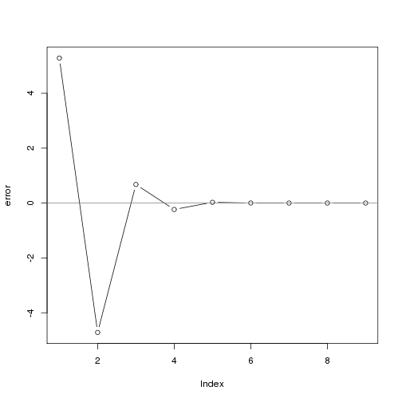

```r
plot(error, type = "b"); abline(h = 0, col = "grey50")
```

### Exercises

- What does the following function do? What would be a good name for it?

```r
f <- function(g) {
  result <- NULL
  function(...) {
    if (is.null(result)) {
      result <<- g(...)
    }
    result
  }
}
runif2 <- f(runif)
runif2(5)
```

```
## [1] 0.8520 0.3369 0.7967 0.1409 0.9580
```

```r
runif2(5)
```

```
## [1] 0.8520 0.3369 0.7967 0.1409 0.9580
```

- Modify `delay_by()` so that instead of delaying by a fixed amount of time, it ensures that a certain amount of time has elapsed since the function was last called. That is, if you called `g <- delay_by(1, f); g(); Sys.sleep(2); g()` there shouldn't be an extra delay.
- Write `wait_until()` which delays execution until a specific time. Or write `run_after()` which only runs a function after a specified time, returning `NULL` otherwise.
- There are three places we could have added a memoise call: why did we choose the one we did?

```r
download <- memoise(dot_every(10, delay_by(1, download.file)))
download <- dot_every(10, memoise(delay_by(1, download.file)))
download <- dot_every(10, delay_by(1, memoise(download.file)))
```

- Why is the `remember()` function inefficient? How could you implement it in more efficient way?

## Output FOs

The next step up in complexity is to modify the output of a function. This could be quite simple, or it could fundamentally change the operation of the function, returning something completely different to its usual output. In this section you'll learn about two simple modifications, `Negate()` and `failwith()`, and two fundamental modifications, `capture_it()` and `time_it()`.

### Minor modifications

`base::Negate` and `plyr::failwith` offer two minor, but useful, modifications of a function that are particularly handy in conjunction with functionals.

`Negate` takes a function that returns a logical vector (a predicate function), and returns the negation of that function. This can be a useful shortcut when the function you have returns the opposite of what you need. Its essence is very simple:

```r
Negate <- function(f) {
  function(...) !f(...)
}
(Negate(is.null))(NULL)
```

```
## [1] FALSE
```

I often use this idea to make a `compact()` function that removes all null elements from a list:

```r
compact <- function(x) Filter(Negate(is.null), x)
```

`plyr::failwith()` turns a function that throws an error into a function that returns a default value when there's an error. Again, the essence of `failwith()` is simple, it's just a wrapper around `try()`, which captures errors and continues execution. (if you haven't seen `try()` before, it's discussed in more detail in the exceptions and debugging chapter):

```r
failwith <- function(default = NULL, f, quiet = FALSE) {
  function(...) {
    out <- default
    try(out <- f(...), silent = quiet)
    out
  }
}
log("a")
```

```
## Error: non-numeric argument to mathematical function
```

```r
failwith(NA, log)("a")
```

```
## [1] NA
```

```r
failwith(NA, log, quiet = TRUE)("a")
```

```
## [1] NA
```

`failwith()` is very useful in conjunction with functionals: instead of the failure propagating and terminating the higher-level loop, you can complete the iteration and then find out what went wrong. For example, imagine you're fitting a set of generalised linear models (glms) to a list of data frames. Sometimes glms fail because of optimisation problems. You still want to try to fit all the models, then once that's complete, look at the data sets that failed to fit:

```r
# If any model fails, all models fail to fit:
models <- lapply(datasets, glm, formula = y ~ x1 + x2 * x3)
# If a model fails, it will get a NULL value
models <- lapply(datasets, failwith(NULL, glm),
  formula = y ~ x1 + x2 * x3)

# remove failed models (NULLs) with compact
ok_models <- compact(models)
# use where to extract the datasets corresponding to failed models
failed_data <- datasets[where(models, is.null)]
```

I think this is a great example of the power of combining functionals and function operators: it makes it easy to succinctly express what you need to solve a common data analysis problem.

### Changing what a function does

Other output function operators can have a more profound affect on the operation of the function. Instead of returning the original return value, we can return some other effect of the function evaluation. Here's two examples:

- Return text that the function `print()`ed:

```r
capture_it <- function(f) {
  function(...) {
    capture.output(f(...))
  }
}
str_out <- capture_it(str)
str(1:10)
```

```
##  int [1:10] 1 2 3 4 5 6 7 8 9 10
```

```r
str_out(1:10)
```

```
## [1] " int [1:10] 1 2 3 4 5 6 7 8 9 10"
```

- Return how long a function took to run:

```r
time_it <- function(f) {
  function(...) {
    system.time(f(...))
  }
}
```

`time_it()` allows us to rewrite some of the code from the functionals chapter:

```r
compute_mean <- list(
  base = function(x) mean(x),
  sum = function(x) sum(x) / length(x)
)
x <- runif(1e6)

# Instead of using an anonymous function to time
lapply(compute_mean, function(f) system.time(f(x)))
```

```
## $base
##    user  system elapsed
##       0       0       0
##
## $sum
##    user  system elapsed
##   0.000   0.000   0.001
```

```r
# We can compose function operators
call_fun <- function(f, ...) f(...)
lapply(compute_mean, time_it(call_fun), x)
```

```
## $base
##    user  system elapsed
##   0.000   0.000   0.001
##
## $sum
##    user  system elapsed
##       0       0       0
```

In this example, there's not a huge benefit to using function operators, because the composition is simple and we're applying the same operator to each function. Generally, using function operators is more effective when you are using multiple operators or if the gap between creating them and using them is large.

### Exercises

- Create a `negative` function that flips the sign of the output from the function to which it's applied.
- The `evaluate` package makes it easy to capture all the outputs (results, text, messages, warnings, errors and plots) from an expression. Create a function like `capture_it()` that also captures the warnings and errors generated by a function.
- Create a FO that tracks files created or deleted in the working directory (Hint: use `setDiff()` and `dir()`). What other global effects do functions have you might want to track?
- Modify the final example to use `fapply()` from the functionals chapter instead of `lapply()`.

## Input FOs

The next step up in complexity is to modify the inputs of a function.Again, you can modify how a function works in a minor way (e.g., prefilling some of the arguments), or fundamentally change the inputs (e.g. converting inputs from scalar to vector, or vector to matrix).

### Prefilling function arguments: partial function application

A common use of anonymous functions is to make a variant of a function that has certain arguments "filled in" already. This is called "partial function application", and is implemented by `pryr::partial`. (Once you have read the computing on the language chapter, I encourage you to read the source code for `partial` and puzzle out how it works - it's only 5 lines of code!)

`partial()` allows us to replace code like

```r
f <- function(a) g(a, b = 1)
compact <- function(x) Filter(Negate(is.null), x)
Map(function(x, y) f(x, y, zs), xs, ys)
```

with

```r
f <- partial(g, b = 1)
compact <- partial(Filter, Negate(is.null))
Map(partial(f, zs = zs), xs, ys)
```

We can use this idea to simplify some of the code we used when working with lists of functions. Instead of:

```r
funs2 <- list(
  sum = function(x, ...) sum(x, ..., na.rm = TRUE),
  mean = function(x, ...) mean(x, ..., na.rm = TRUE),
  median = function(x, ...) median(x, ..., na.rm = TRUE)
)
```

We can write:

```r
library(pryr)
funs2 <- list(
  sum = partial(sum, na.rm = TRUE),
  mean = partial(mean, na.rm = TRUE),
  median = partial(median, na.rm = TRUE)
)
```

But if you look closely you'll notice we're just applying a function to every element in a list, and that's the job of `lapply`. This allows us to reduce the code still further::

```r
funs <- c(sum = sum, mean = mean, median = median)
funs2 <- lapply(funs, partial, na.rm = TRUE)
```

Let's think about a similar, but subtly different case. Say we have a numeric vector and we want to generate a list of trimmed means with that amount of trimming. The following code doesn't work because we want the first argument of `partial` to be fixed to mean. We could try specifying the argument name because fixed matching overrides positional, but that doesn't work because the `trims` end up supplied to the first argument of `mean`.

```r
(trims <- seq(0, 0.9, length = 5))
```

```
## [1] 0.000 0.225 0.450 0.675 0.900
```

```r
funs3 <- lapply(trims, partial, `_f` = mean)
sapply(funs3, call_fun, c(1:100, (1:50) * 100))
```

```
## Error: 'trim' must be numeric of length one
```

Instead we could use an anonymous function

```r
funs4 <- lapply(trims, function(t) partial(mean, trim = t))
funs4[[1]]
```

```
## function (...)
## mean(trim = t, ...)
##
```

```r
sapply(funs4, call_fun, c(1:100, (1:50) * 100))
```

```
## [1] 75.5 75.5 75.5 75.5 75.5
```

But that doesn't work because each function gets a promise to evaluate `t`, and that promise isn't evaluated until all of the functions are run, by which time `t = 0.9`. To make it work you need to manually force the evaluation of t:

```r
funs5 <- lapply(trims, function(t) {
  force(t)
  partial(mean, trim = t)
})
funs5[[1]]
```

```
## function (...)
## mean(trim = t, ...)
##
```

```r
sapply(funs5, call_fun, c(1:100, (1:50) * 100))
```

```
## [1] 883.7 235.6  75.5  75.5  75.5
```

When writing functionals, you can expect your users to know of `partial()` and not use `...` For example, instead of implementing `lapply()` like:

```r
lapply2 <- function(x, f, ...) {
  out <- vector("list", length(x))
  for (i in seq_along(x)) {
    out[[i]] <- f(x[[i]], ...)
  }
  out
}
unlist(lapply2(1:5, log, base = 10))
```

```
## [1] 0.0000 0.3010 0.4771 0.6021 0.6990
```

we could implement it as:

```r
lapply3 <- function(x, f) {
  out <- vector("list", length(x))
  for (i in seq_along(x)) {
    out[[i]] <- f(x[[i]])
  }
  out
}
unlist(lapply3(1:5, partial(log, base = 10)))
```

```
## [1] 0.0000 0.3010 0.4771 0.6021 0.6990
```

### Changing input types

Instead of a minor change to the function's inputs, it's also possible to make a function work with a fundamentally different type of data. There are a few existing functions along these lines:

- `base::Vectorize` converts a scalar function to a vector function. `Vectorize` takes a non-vectorised function and vectorises with respect to the arguments given in the `vectorizge.args` parameter. This doesn't give you any magical performance improvements, but it is useful if you want a quick and dirty way of making a vectorised function.

  A mildly useful extension of `sample` would be to vectorize it with respect to size: this would allow you to generate multiple samples in one call.

```r
sample2 <- Vectorize(sample, "size", SIMPLIFY = FALSE)
sample2(1:5, c(1, 1, 3))
```

```
## [[1]]
## [1] 5
##
## [[2]]
## [1] 4
##
## [[3]]
## [1] 3 1 2
```

```r
sample2(1:5, 5:3)
```

```
## [[1]]
## [1] 2 4 5 1 3
##
## [[2]]
## [1] 4 5 3 2
##
## [[3]]
## [1] 2 5 1
```

```
In this example we have used `SIMPLIFY = FALSE` to ensure that our newly vectorised function always returns a list. This is usually what you want.
```

- `splat` converts a function that takes multiple arguments to a function that takes a single list of arguments.

```r
splat <- function (f) {
  function(args) {
    do.call(f, args)
  }
}
```

```
This is useful if you want to invoke a function with varying arguments:
```

```r
x <- c(NA, runif(100), 1000)
args <- list(
  list(x),
  list(x, na.rm = TRUE),
  list(x, na.rm = TRUE, trim = 0.1)
)
lapply(args, splat(mean))
```

[output not shown]

- `plyr::colwise()` converts a vector function to one that works with data frames:

```r
median(mtcars)
```

```
## Error: need numeric data
```

```r
median(mtcars$mpg)
```

[output not shown]

```r
plyr::colwise(median)(mtcars)
```

```
## Error: need numeric data
```

### Exercises

- Our previous `download()` function will only download a single file. How can you use `partial()` and `lapply()` to create a function that downloads multiple files at once? What are the pros and cons of using `partial()` vs. writing a function by hand?
- Read the source code for `plyr::colwise()`. How does code work? It performs three main tasks. What are they? How could you make `colwise` simpler by implementing each separate task as a function operator? (Hint: think about `partial`)
- Write FOs that convert a function to return a matrix instead of a data frame, or a data frame instead of a matrix. (If you already know [[S3]], make these methods of `as.data.frame` and `as.matrix`)
- You've seen five functions that modify a function to change it's output from one form to another. What are they? Draw a table: what should go in the rows and what should go in the columns? What function operators might you want to write to fill in the missing cells? Come up with example use cases.
- Look at all the examples of using an anonymous function to partially apply a function in this and the previous chapter. Replace the anonymous function with `partial`. What do you think of the result? Is it easier or harder to read?

## Combining FOs

Instead of operating on single functions, function operators can take multiple functions as input. One simple example of this is `plyr::each()` which takes a list of vectorised functions and returns a single function that applies each in turn to the input:

```r
summaries <- plyr::each(mean, sd, median)
summaries(1:10)
```

```
##   mean     sd median
##  5.500  3.028  5.500
```

Two more complicated examples are combining functions through composition, or through boolean algebra. These are glue that join multiple functions together.

### Function composition

An important way of combining functions is through composition: `f(g(x))`. Composition takes a list of functions and applies them sequentially to the input. It's a replacement for the common anonymous function pattern where you chain together multiple functions to get the result you want:

```r
sapply(mtcars, function(x) length(unique(x)))
```

```
##  mpg  cyl disp   hp drat   wt qsec   vs   am gear carb
##   25    3   27   22   22   29   30    2    1    3    6
```

A simple version of compose looks like this:

```r
compose <- function(f, g) {
  function(...) f(g(...))
}
```

(`pryr::compose()` provides a fuller-featured alternative that can accept multiple functions).

This allows us to write:

```r
sapply(mtcars, compose(length, unique))
```

```
##  mpg  cyl disp   hp drat   wt qsec   vs   am gear carb
##   25    3   27   22   22   29   30    2    1    3    6
```

Mathematically, function composition is often denoted with an infix operator, o, `(f o g)(x)`. Haskell, a popular functional programming language, uses `.` in a similar manner. In R, we can create our own infix function that works similarly:

```r
"%.%" <- compose
sapply(mtcars, length %.% unique)
```

```
##  mpg  cyl disp   hp drat   wt qsec   vs   am gear carb
##   25    3   27   22   22   29   30    2    1    3    6
```

```r
sqrt(1 + 8)
```

```
## [1] 3
```

```r
compose(sqrt, `+`)(1, 8)
```

```
## [1] 3
```

```r
(sqrt %.% `+`)(1, 8)
```

```
## [1] 3
```

Compose also allows for a very succinct implement of `Negate`: it's just a partially evaluated version of `compose()`.

```r
Negate <- partial(compose, `!`)
```

We could also implement the standard deviation by breaking it down into a separate set of function compositions:

```r
square <- function(x) x ^ 2
deviation <- function(x) x - mean(x)

sd <- sqrt %.% mean %.% square %.% deviation
sd(1:10)
```

```
## [1] 2.872
```

This type of programming is called tacit or point-free programming. (The term point free comes from use the of the word point to refer values in topology; this style is also derogatorily known as pointless). In this style of programming you don't explicitly refer to variables, focussing on the high-level composition of functions, rather than the low-level flow of data. Since we're using only functions and not parameters, we use verbs and not nouns, and this style leads to code that focusses on what's being done, not what it's being done to. This style is common in Haskell, and is the typical style in stack based programming languages like Forth and Factor. It's not a terribly natural or elegant style in R, but it is a useful tool to have in your toolbox.

`compose()` is particularly useful in conjunction with `partial()`, because `partial()` allows you to supply additional arguments to the functions being composed. One nice side effect of this style of programming is that it keeps the arguments to each function near the function name. This is important because code gets harder to understand as the size of the chunk of code you have to hold in your head grows.

Below I take the example from the first section of the chapter and modify it to use the two styles of function composition defined above. They are both longer than the original code but maybe easier to understand because the function and its arguments are closer together. Note that we still have to read them from right to left (bottom to top): the first function called is the last one written. We could define `compose()` to work in the opposite direction, but in the long run, this is likely to lead to confusion since we'd create a small part of the langugage that reads differently to every other part.

```r
download <- dot_every(10, memoise(delay_by(1, download.file)))

download <- pryr::compose(
  partial(dot_every, 10),
  memoise,
  partial(delay_by, 1),
  download.file
)

download <- partial(dot_every, 10) %.%
  memoise %.%
  partial(delay_by, 1) %.%
  download.file
```

### Logical predicates and boolean algebra

When I use `Filter()` and other functionals that work with logical predicates, I often find myself using anonymous functions to combine multiple conditions:

```r
Filter(function(x) is.character(x) || is.factor(x), iris)
```

As an alternative, we could define some function operators that combine logical predicates:

```r
and <- function(f1, f2) {
  function(...) {
    f1(...) && f2(...)
  }
}
or <- function(f1, f2) {
  function(...) {
    f1(...) || f2(...)
  }
}
not <- function(f1) {
  function(...) {
    !f1(...)
  }
}
```

which would allow us to write:

```r
Filter(or(is.character, is.factor), iris)
```

This allows us to express arbitrarily complicated boolean expressing involving functions in a succinct way.

### Exercises

- Implement your own version of `compose` using `Reduce` and `%.%`. For bonus points, do it without calling `function`.
- Extend `and()` and `or()` to deal with any number of input functions. Can you do it with `Reduce()`? Can you keep them lazy (so e.g. for `and()` the function returns as soon as it sees the first `FALSE`)?
- Implement the `xor()` binary operator. Implement it using the existing `xor()` function. Implement it as a combination of `and()` and `or()`. What are the advantages and disadvantages of each approach? Also think about what you'll call the resulting function, and how you might need to change the names of `and()`, `not()` and `or()` in order to keep them consistent.
- Above, we implemented boolean algebra for functions that return a logical function. Implement elementary algebra (`plus()`, `minus()`, `multiply()`, `divide()`, `exponentiate()`, `log()`) for functions that return numeric vectors.

## The common pattern and a subtle bug

Most function operators we've seen follow a similar pattern:

```r
funop <- function(f, otherargs) {
  function(...) {
    # maybe do something
    res <- f(...)
    # maybe do something else
    res
  }
}
```

There's a subtle problem with this implementation. It does not work well with `lapply()` because `f` is lazily evaluated. This means that if you give `lapply()` a list of functions and a FO to apply it to each of them, it will look like it repeatedly applied the FO to the last function:

```r
wrap <- function(f) {
  function(...) f(...)
}
fs <- list(sum = sum, mean = mean, min = min)
gs <- lapply(fs, wrap)
gs$sum(1:10)
```

```
## [1] 1
```

```r
environment(gs$sum)$f
```

```
## function (..., na.rm = FALSE)  .Primitive("min")
```

Another problem is that as designed, we have to pass in a funtion object, not the name of a function, which is often convenient. We can solve both problems by using `match.fun()`: it forces evaluation of `f`, and will find the function object if given its name:

```r
wrap2 <- function(f) {
  f <- match.fun(f)
  function(...) f(...)
}
fs <- c(sum = "sum", mean = "mean", min = "min")
hs <- lapply(fs, wrap2)
hs$sum(1:10)
```

```
## [1] 55
```

```r
environment(hs$sum)$f
```

```
## function (..., na.rm = FALSE)  .Primitive("sum")
```

### Exercises

- Why does the following code (from [stackoverflow](http://stackoverflow.com/questions/8440675)) not do what you expect?

```r
a <- list(0, 1)
b <- list(0, 1)

# return a linear function with slope a and intercept b.
f <- function(a, b) function(x) a * x + b

# create a list of functions with different parameters.
fs <- Map(f, a, b)

fs[[1]](3)
```

```
## [1] 4
```

```
How can you modify `f` so that it works correctly?
```

# Metaprogramming

''Flexibility in syntax, if it does not lead to ambiguity, would seem a reasonable thing to ask of an interactive programming language.'' --- Kent Pitman, http://www.nhplace.com/kent/Papers/Special-Forms.html

R has powerful tools for computing not only on values, but also on the actions that lead to those values. These tools are powerful and magical, and one of the most surprising features if you're coming from another programming language. Take the following simple snippet of code that draws a sine curve:

[figure not shown]

```r
x <- seq(0, 2 * pi, length = 100)
sinx <- sin(x)
plot(x, sinx, type = "l")
```

Look at the labels on the axes! How did R know that the variable on the x axis was called `x` and the variable on the y axis was called `sinx`? In most programming languages, you can only access values of the arguments provided to functions, but in R you can also access the expression used to computing them. Combined with R's lazy evaluation mechanism this gives function authors considerable power to both access the underlying expression and do special things with it.

Techniques based on these tools are generally called "computing on the language", and in R provide a set of tools with power equivalent to functional and object oriented programming. This chapter will introduce you to the basic ideas of special evaluation, show you how they are used in base R, and how you can use them to create your own functions that save typing for interactive analysis. These tools are very useful for developing convenient user-facing functions because they can dramatically reduce the amount of typing required to specify an action.

Computing on the language is an extremely powerful tool, but it can also create code that is hard for others to understand and is substantially harder to program with. Before you use it, make sure that you have exhausted all other possibilities. You'll also learn about the downsides: because these tools work with expressions rather than values this increases ambiguity in the function call, and makes the function difficult to call from another function.

The following chapters [[expressions]] and [[special-environments]], expand on these ideas, discussing the underlying data structures and how you can understand and manipulate them to create new tools.

In this chapter you'll learn:

- how many functions such as `plot()` and `data.frame()` capture the names of the variable supplied to them, and the downsides of this technique.
- Manipulate a data frame by referring to the variables: `subset()`, `transform()`, `plyr::mutate()`, `plyr::arrange()`, `plyr::summarise()`, `with()`
- Work around non-standard evaluation with (like lattice functions) `substitute`.
- Capture an expression for later evaluation: ggplot2 and plyr
- Use formulas to describe computations: `lm()` and the lattice package

## Capturing expressions

The tool that makes non-standard evaluation possible in R is `substitute()`. It looks at a function argument, and instead of seeing the value, it looks to see how the value was computed:

```r
f <- function(x) {
  substitute(x)
}
f(1:10)
```

```
## 1:10
```

```r
f(x)
```

```
## x
```

```r
f(x + y ^ 2 / z + exp(a * sin(b)))
```

```
## x + y^2/z + exp(a * sin(b))
```

We won't worry yet about exactly what sort of object `substitute()` returns (that's the topic of the [[Expressions]] chapter), but we'll call it an expression. (Note that it's not the same thing as returned by the `expression()` function: we'll call that an expression *object*.)

`substitute()` works because function arguments in R are only evaluated when they are needed, not automatically when the function is called. This means that function arguments are not just a simple value, but instead store both the expression to compute the value and the environment in which to compute it. Together these two things are called a **promise**. Most of the time in R, you don't need to know anything about promises because the first time you access a promise it is seamlessly evaluated, returning its value.

We need one more function if we want to understand how `plot()` and `data.frame()` work: `deparse()`. This function takes an expression and converts it to a character vector.

```r
g <- function(x) deparse(substitute(x))
g(1:10)
```

```
## [1] "1:10"
```

```r
g(x)
```

```
## [1] "x"
```

```r
g(x + y ^ 2 / z + exp(a * sin(b)))
```

```
## [1] "x + y^2/z + exp(a * sin(b))"
```

There's one important caveat with `deparse()`: it can return a multiple strings if the input is long:

```r
g(a + b + c + d + e + f + g + h + i + j + k + l + m + n + o + p + q + r + s + t + u + v + w + x + y + z)
```

[output not shown]

If you need a single string, you can work around this by using the `width.cutoff` argument (which has a maximum value of 500), or by joining the lines back together again with `paste()`.

You might wonder why we couldn't use our original `f()` to compute `g()`. Let's try it:

```r
g <- function(x) deparse(f(x))
g(1:10)
```

```
## [1] "x"
```

```r
g(x)
```

```
## [1] "x"
```

```r
g(x + y ^ 2 / z + exp(a * sin(b)))
```

```
## [1] "x"
```

This is one of the downsides of functions that use `substitute()`: because they use the expression, not the value, of an argument, it becomes harder to call them from other functions. We'll talk more about this problem and some remedies later on.

There are a lots of function in base R that use these ideas. Some use them to avoid quotes:

```r
library(ggplot2)
library("ggplot2")
```

Others use them to provide default labels. For example, `plot.default()` has code that basically does (the real code is more complicated because of the way base plotting methods work, but it's effectively the same):

```r
plot.default <- function(x, y = NULL, xlabel = NULL, ylabel = NULL, ...) {
    ...
    xlab <- if (is.null(xlabel) && !missing(x)) deparse(substitute(x))
    ylab <- if (is.null(xlabel) && !missing(y)) deparse(substitute(y))
    ...
}
```

If a label is not set and the variable is present, then the expression used to generate the value of `x` is used as a default value for the label on the x axis.

`data.frame()` does a similar thing. It automatically labels variables with the expression used to compute them:

```r
x <- 1:4
y <- letters[1:4]
names(data.frame(x, y))
```

```
## [1] "x" "y"
```

This wouldn't be possible in most programming langauges because functions usually only see values (e.g. `1:4` and `c("a", "b", "c", "d")`), not the expressions that created them (`x` and `y`).

## Non-standard evaluation in subset

Just printing out the expression used to generate an argument value is useful, but we can do even more with the unevaluated function. For example, take `subset()`. It's a useful interactive shortcut for subsetting data frames: instead of repeating the data frame you're working with again and again, you can save some typing:

```r
subset(mtcars, cyl == 4)
# equivalent to:
# mtcars[mtcars$cyl == 4, ]

subset(mtcars, vs == am)
# equivalent to:
# mtcars[mtcars$vs == mtcars$am, ]
```

Subset is special because `vs == am` or `cyl == 4` aren't evaluated in the global environment: instead they're evaluated in the data frame. In other words, `subset()` implements different [[scoping|Scoping]] rules so instead of looking for those variables in the current environment, `subset()` looks in the specified data frame. This is called **non-standard evaluation**: you are deliberately breaking R's usual rules in order to do something special.

How does `subset()` work? We've already seen how to capture the expression that represents an argument, rather than its value, so we just need to figure out how to evaluate that expression in the right context: i.e. `cyl` should be interpreted as `mtcars$cyl`. To do this we need `eval()`, which takes an expression and evaluates it in the specified environment.

But before we can do that, we need to learn one more useful function: `quote()`. It's similar to `substitute()` but it always gives you back exactly the expression you entered. This makes it useful for interactive experimentation.

```r
quote(1:10)
```

```
## 1:10
```

```r
quote(x)
```

```
## x
```

```r
quote(x + y ^ 2 / z + exp(a * sin(b)))
```

```
## x + y^2/z + exp(a * sin(b))
```

Now let's experiment with `eval()`. If you only provide one argument, it evaluates the expression in the current environment. This makes `eval(quote(x))` exactly equivalent to typing `x`, regardless of what `x` is:

```r
eval(quote(x <- 1))
eval(quote(x))
```

[output not shown]

```r
eval(quote(cyl))
```

```
## Error: object 'cyl' not found
```

Note that `quote()` and `eval()` are basically opposites. In the example below, each `eval()` peels off one layer of quoting.

```r
quote(2 + 2)
```

```
## 2 + 2
```

```r
eval(quote(2 + 2))
```

```
## [1] 4
```

```r
quote(quote(2 + 2))
```

```
## quote(2 + 2)
```

```r
eval(quote(quote(2 + 2)))
```

```
## 2 + 2
```

```r
eval(eval(quote(quote(2 + 2))))
```

```
## [1] 4
```

What will this code return?

```r
eval(quote(eval(quote(eval(quote(2 + 2))))))
```

The second argument to `eval()` controls which environment the code is evaluated in:

```r
x <- 10
eval(quote(x))
```

[output not shown]

```r
e <- new.env()
e$x <- 20
eval(quote(x), e)
```

```
## [1] 20
```

Instead of an environment, the second argument can also be a list or a data frame. This works because an environment is basically a set of mappings between names and values, in the same way as a list or data frame.

```r
eval(quote(x), list(x = 30))
```

```
## [1] 30
```

```r
eval(quote(x), data.frame(x = 40))
```

```
## [1] 40
```

This is basically what we want for `subset()`:

```r
eval(quote(cyl == 4), mtcars)
```

```
##  [1] FALSE FALSE FALSE FALSE FALSE FALSE FALSE FALSE FALSE FALSE FALSE
## [12] FALSE FALSE FALSE FALSE FALSE FALSE FALSE FALSE FALSE FALSE FALSE
## [23] FALSE FALSE FALSE FALSE FALSE FALSE FALSE FALSE FALSE FALSE
```

```r
eval(quote(vs == am), mtcars)
```

```
##  [1] NA NA NA NA NA NA NA NA NA NA NA NA NA NA NA NA NA NA NA NA NA NA NA
## [24] NA NA NA NA NA NA NA NA NA
```

We can combine `eval()` and `substitute()` together to write `subset()`: we can capture the call representing the condition, evaluate it in the context of the data frame, and then use the result for subsetting:

```r
subset2 <- function(x, condition) {
  condition_call <- substitute(condition)
  r <- eval(condition_call, x)
  x[r, ]
}
subset2(mtcars, cyl == 6)
```

[output not shown]

When you first start using `eval()` it's easy to make mistakes. Here's a common one: forgetting to quote the input:

```r
eval(cyl, mtcars)
```

```
## Error: object 'cyl' not found
```

```r
# Carefully look at the difference to this error
eval(quote(cyl), mtcars)
```

```
##  [1] 0.9697 0.9697 0.6465 0.9697 1.2929 0.9697 1.2929 0.6465 0.6465 0.9697
## [11] 0.9697 1.2929 1.2929 1.2929 1.2929 1.2929 1.2929 0.6465 0.6465 0.6465
## [21] 0.6465 1.2929 1.2929 1.2929 1.2929 0.6465 0.6465 0.6465 1.2929 0.9697
## [31] 1.2929 0.6465
```

### Exercises

- The real subset function (`subset.data.frame()`) does two other things to the result. What are they?
- The other component of the real subset function is variable selection. It allows you to work with variable names like they are positions, so you can do things like `subset(mtcars, , -cyl)` to drop the cylinder variable, or `subset(mtcars, , disp:drat)` to select all the variables between `disp` and `drat`. How does select work? I've made it easier to understand by extracting it out into its own function:

```r
select <- function(df, vars) {
  vars <- substitute(vars)
  var_pos <- setNames(as.list(seq_along(df)), names(df))
  pos <- eval(vars, var_pos)
  df[, pos, drop = FALSE]
}
select(mtcars, -cyl)
```

```
##                        mpg     disp     hp   drat     wt   qsec    vs   am
## Mazda RX4           1.0453 0.011364 0.7499 1.0844 0.8144 0.9222 0.000
## Mazda RX4 Wag       1.0453 0.011364 0.7499 1.0844 0.8936 0.9536 0.000
## Datsun 710          1.1349 0.007671 0.6340 1.0705 0.7211 1.0427 2.286
## Hornet 4 Drive      1.0652 0.018325 0.7499 0.8564 0.9993 1.0892 2.286
## Hornet Sportabout   0.9308 0.025569 1.1930 0.8758 1.0692 0.9536 0.000
## Valiant             0.9009 0.015981 0.7158 0.7674 1.0755 1.1329 2.286
## Duster 360          0.7118 0.025569 1.6702 0.8925 1.1096 0.8875 0.000
## Merc 240D           1.2145 0.010419 0.4227 1.0260 0.9915 1.1205 2.286
## Merc 230            1.1349 0.010000 0.6476 1.0899 0.9791 1.2830 2.286
## Merc 280            0.9557 0.011904 0.8385 1.0899 1.0692 1.0253 2.286
## Merc 280C           0.8860 0.011904 0.8385 1.0899 1.0692 1.0589 2.286
## Merc 450SE          0.8163 0.019589 1.2271 0.8536 1.2651 0.9749 0.000
## Merc 450SL          0.8611 0.019589 1.2271 0.8536 1.1594 0.9861 0.000
## Merc 450SLC         0.7566 0.019589 1.2271 0.8536 1.1749 1.0085 0.000
## Cadillac Fleetwood  0.5177 0.033524 1.3975 0.8147 1.6318 1.0074 0.000
## Lincoln Continental 0.5177 0.032672 1.4657 0.8341 1.6859 0.9984 0.000
## Chrysler Imperial   0.7317 0.031251 1.5680 0.8981 1.6614 0.9760 0.000
## Fiat 128            1.6127 0.005590 0.4499 1.1344 0.6838 1.0908 2.286
## Honda Civic         1.5131 0.005377 0.3545 1.3708 0.5020 1.0376 2.286
## Toyota Corolla      1.6874 0.005050 0.4431 1.1733 0.5704 1.1149 2.286
## Toyota Corona       1.0702 0.008530 0.6613 1.0288 0.7662 1.1211 2.286
## Dodge Challenger    0.7715 0.022586 1.0226 0.7674 1.0941 0.9452 0.000
## AMC Javelin         0.7566 0.021592 1.0226 0.8758 1.0677 0.9693 0.000
## Camaro Z28          0.6620 0.024859 1.6702 1.0371 1.1936 0.8634 0.000
## Pontiac Firebird    0.9557 0.028410 1.1930 0.8564 1.1951 0.9552 0.000
## Fiat X1-9           1.3588 0.005611 0.4499 1.1344 0.6014 1.0589 2.286
## Porsche 914-2       1.2941 0.008544 0.6204 1.2317 0.6652 0.9356 0.000
## Lotus Europa        1.5131 0.006755 0.7703 1.0482 0.4703 0.9468 2.286
## Ford Pantera L      0.7864 0.024930 1.7997 1.1733 0.9853 0.8124 0.000
## Ferrari Dino        0.9806 0.010299 1.1930 1.0065 0.8610 0.8684 0.000
## Maserati Bora       0.7466 0.021379 2.2838 0.9843 1.1096 0.8180 0.000
## Volvo 142E          1.0652 0.008594 0.7431 1.1428 0.8641 1.0421 2.286
##                       gear   carb
## Mazda RX4           1.0847 1.4222
## Mazda RX4 Wag       1.0847 1.4222
## Datsun 710          1.0847 0.3556
## Hornet 4 Drive      0.8136 0.3556
## Hornet Sportabout   0.8136 0.7111
## Valiant             0.8136 0.3556
```

[output cut: 11 more lines]

```
## Fiat 128            1.0847 0.3556
## Honda Civic         1.0847 0.7111
## Toyota Corolla      1.0847 0.3556
## Toyota Corona       0.8136 0.3556
## Dodge Challenger    0.8136 0.7111
## AMC Javelin         0.8136 0.7111
## Camaro Z28          0.8136 1.4222
## Pontiac Firebird    0.8136 0.7111
## Fiat X1-9           1.0847 0.3556
## Porsche 914-2       1.3559 0.7111
## Lotus Europa        1.3559 0.7111
## Ford Pantera L      1.3559 1.4222
## Ferrari Dino        1.3559 2.1333
## Maserati Bora       1.3559 2.8444
## Volvo 142E          1.0847 0.7111
```

- What does `evalq()` do? Use it to reduce the amount of typing for the examples above that use both `eval()` and `quote()`

## Scoping issues

While it certainly looks like our `subset2()` function works, whenever we're working with expressions instead of values, we need to test a little more carefully. For example, you might expect that the following uses of `subset2()` should all return the same value because each variable refers to the same value:

```r
y <- 4
x <- 4
condition <- 4
condition_call <- 4

subset2(mtcars, cyl == 4)
```

```
##  [1] mpg  cyl  disp hp   drat wt   qsec vs   am   gear carb
## <0 rows> (or 0-length row.names)
```

```r
subset2(mtcars, cyl == y)
```

```
##  [1] mpg  cyl  disp hp   drat wt   qsec vs   am   gear carb
## <0 rows> (or 0-length row.names)
```

```r
subset2(mtcars, cyl == x)
```

[output not shown]

[output cut: 5874 more lines]

[output not shown]